# What is my average time to crochet a hat?

Chad Worley

2024 Sep 27

# Research Question

Since COVID, I have picked up crochet as a hobby. One of my favorite projects is making a beanie hat with medium weight yarn, specifically the Lion Brand Landscapes yarn. I appreciate that if I make the hat in continuous rounds, the gradient appears to make stripes with beautiful color combinations.

I wondered what is my average time to crochet one of these beanie hats?

# Data Acquisition

For this project it is a bit strange to define the larger population. The larger population is the infinitely many hats I could crochet while still at my current skill level. I have been crocheting for years, so I do not think I am getting much faster or slower. But, in reality, will I ever even make 100 of these hats? Probably not.

I can still try to estimate the true underlying [expected time](https://en.wikipedia.org/wiki/Expected_value) per hat.

Many factors influence my crochet speed. How focused am I? Am I listening to fast music or a slow podcast? Is the yarn full of breaks? But also, I’m sure there is some natural fluctuations with no rhyme or reason.

Because this is just a quick high-school project, I decided that by timing my next 6 hats, I think the sample is representative enough of the population.

I started the timer whenever I picked up the project and I stopped the timer whenever I put the project down. I included the time of sewing in the ends. Below are the times (in minutes) of 6 hats:

191, 216, 185, 258, 220, 185

# Analysis

Two confidence intervals were determined using two techniques: formulas and bootstrapping.

### Formulaic confidence interval

The data were entered into a spreadsheet. The `=AVERAGE()` function produced the sample mean ($\bar{x}$). The `=STDEV()` function produced the sample standard deviation ($s$).
$$\bar{x}=209.17$$
$$s=28.45$$
Of course, my sample size ($n$) was 6.
$$n=6$$

The formula for a confidence interval is shown below.
$$\bar{x}\pm \frac{2s}{\sqrt{n}}$$
By plugging in the values, I determined the confidence interval: $[185.9,232.4]$

### Bootstrap confidence interval

In bootstrapping, we resample, with replacement, from the original sample to generate many resamplings, each with the same sample size as the original. In other words, we use the [empirical distribution](https://en.wikipedia.org/wiki/Empirical_distribution_function) to generate a bunch of new possible samples. The goal is to estimate how much the sample means vary.

The empirical distribution could be depicted with the spinner below.

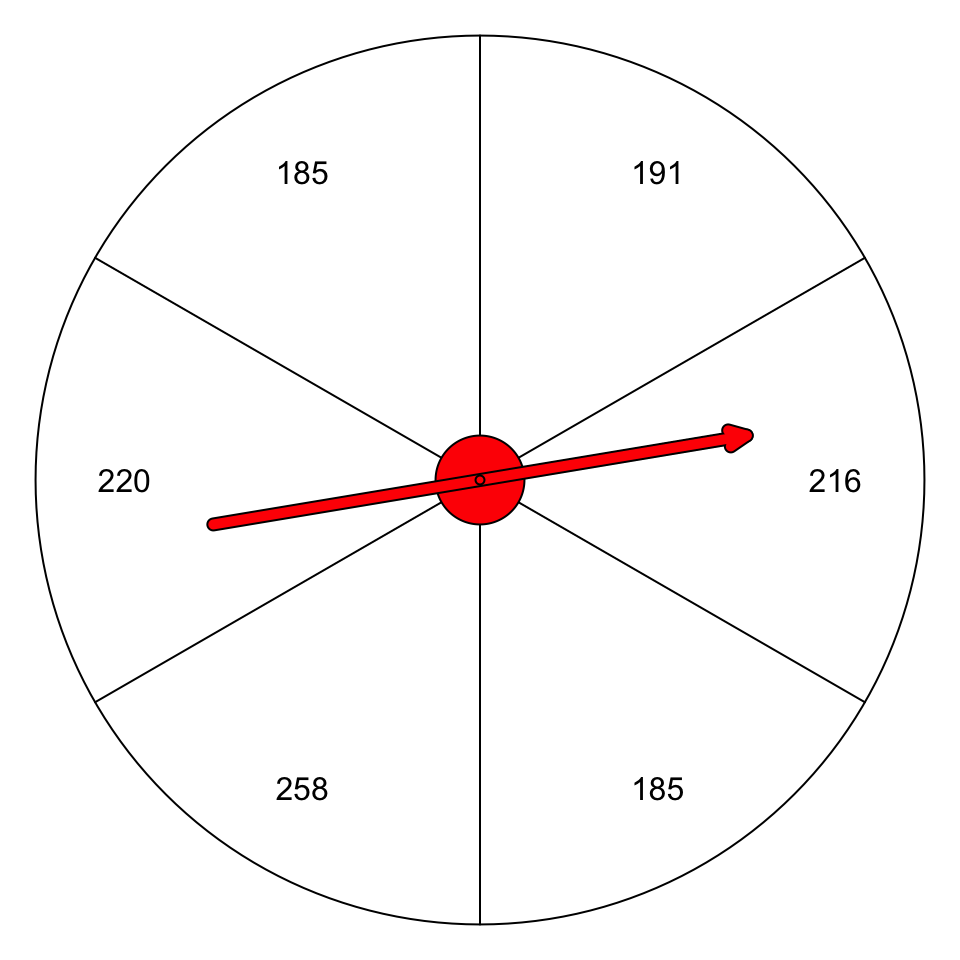

We can imagine making many new samples with that empirical spinner.

| rep_num | spin_1 | spin_2 | spin_3 | spin_4 | spin_5 | spin_6 | average |
| --- | --- | --- | --- | --- | --- | --- | --- |
| 1 | 191 | 191 | 191 | 216 | 216 | 185 | 198.3333 |
| 2 | 220 | 191 | 258 | 258 | 185 | 185 | 216.1667 |
| 3 | 220 | 185 | 185 | 191 | 185 | 185 | 191.8333 |
| 4 | 216 | 220 | 185 | 185 | 216 | 258 | 213.3333 |
| 5 | 185 | 220 | 216 | 191 | 220 | 185 | 202.8333 |
| 6 | 185 | 216 | 216 | 258 | 216 | 185 | 212.6667 |
| 7 | 216 | 216 | 185 | 191 | 185 | 191 | 197.3333 |
| 8 | 191 | 185 | 258 | 185 | 185 | 258 | 210.3333 |
| 9 | 220 | 191 | 258 | 216 | 185 | 220 | 215.0000 |
| 10 | 220 | 258 | 258 | 185 | 191 | 191 | 217.1667 |

To do this in a spreadsheet, I put the 6 original values in cell range A1:F1. To sample with replacement, I used the formula `=INDEX($A$1:$F$1,1,RANDBETWEEN(1,6))`. This formula was repeated in all cells in range A2:F1001 (to have 1000 repetitions). In cell H2, I used `=AVERAGE(A2:F2)`, and then dragged the formula down the whole column. Thus, in column H there were 1000 means. I’ve made a histogram of those means.

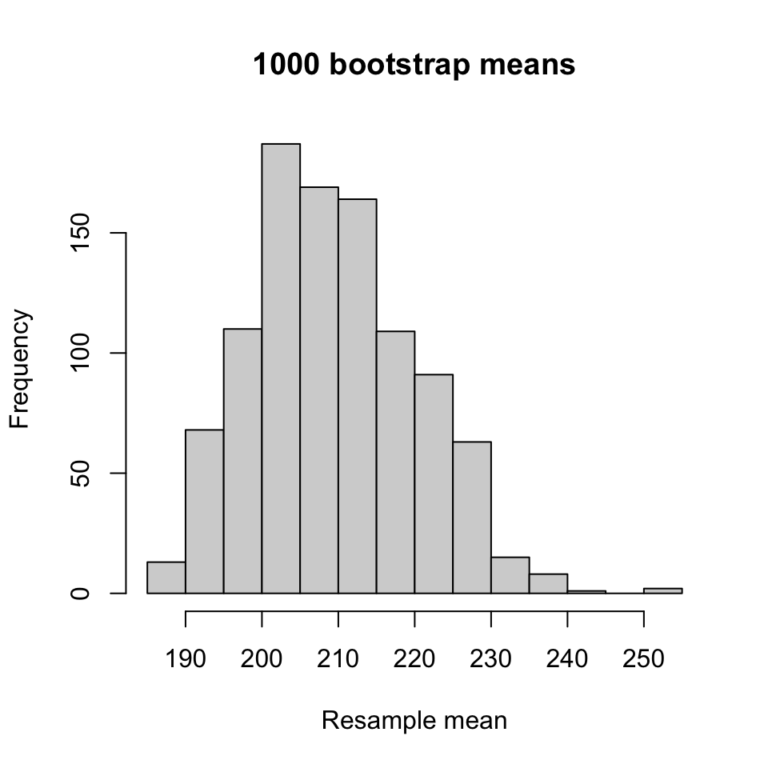

By identifying the 2.5th percentile and the 97.5th percentile, we find the confidence interval: $[191.2,231.3]$.

# Conclusion

Both confidence intervals agree quite closely. Because we have a small sample size, I will stick with the bootstrap method as my final answer. My conclusion is that my expected time is between 191.2 and 231.3 minutes.

Now, remember, the phrase “expected time” is a bit of a misnomer. We could say that we expect if I made a million hats (while keeping my skill level constant), we think the average time will be between 191.2 and 231.3 minutes.